# tarea1

linares_german

17/9/2021

# PRÁTICA 0

#### Usando la función sample crea un vector dado_honesto con 100 números del 1 al 6. Haz una tabla de frecuencias absolutas (de dos maneras, con table y dplyr) y una tabla de frecuencias relativas.

```r
library(tidyverse)
library(dplyr)

dado_honesto = sample(1:6,100, replace = TRUE)

tabla_as_df_dado_honesto <- as.data.frame(table(dado_honesto))
tabla_dado_honesto <- table(dado_honesto)
tabla_dado_honesto
```

```
## dado_honesto
##  1  2  3  4  5  6
## 14 16 19 13 26 12
```

##### Tabla frecuencias relativas

```r
prop.table(table(dado_honesto))
```

```
## dado_honesto
##    1    2    3    4    5    6
## 0.14 0.16 0.19 0.13 0.26 0.12
```

#### A continuación crea un nuevo vector dado_cargado de manera que la probabilidad de que el número elegido valga 6 sea el doble que la probabilidad de elegir cualquiera de los cinco números restantes. Lee la ayuda de sample si lo necesitas. De nuevo, haz tablas de frecuencias absolutas y relativas de este segundo vector.

```r
dado_cargado = sample(1:6, 100, replace = TRUE, prob = c(0.14,0.14,0.14,0.14,0.14,0.3))
tabla_as_df_dado_cargado <- as.data.frame(table(dado_cargado))
tabla_dado_cargado <- table(dado_cargado)
```

##### Tabla frecuencias relativas

```r
prop.table(table(dado_cargado))
```

```
## dado_cargado
##    1    2    3    4    5    6
## 0.15 0.11 0.12 0.16 0.17 0.29
```

#### Utiliza las funciones rep y seq para crear tres vectores v1, v2 y v3 con estos elementos respectivamente:

##### rep

```r
v1 <- rep(c(4,3,2,1), each=4)
v2 <- rep(c(1,2,3,4,5), c(1,2,3,4,5))
v3 <- rep(c(1,2,3,4), 4)
v1
```

```
##  [1] 4 4 4 4 3 3 3 3 2 2 2 2 1 1 1 1
```

```r
v2
```

```
##  [1] 1 2 2 3 3 3 4 4 4 4 5 5 5 5 5
```

```r
v3
```

```
##  [1] 1 2 3 4 1 2 3 4 1 2 3 4 1 2 3 4
```

##### seq

```r
v1_2 <- seq(from = 4, to = 1)
v2_2 <- rep(seq(1, 5, by=1), c(1,2,3,4,5))
v3_2 <- rep(seq(1,4,by=1),4)
v1_2
```

```
## [1] 4 3 2 1
```

```r
v2_2
```

```
##  [1] 1 2 2 3 3 3 4 4 4 4 5 5 5 5 5
```

```r
v3_2
```

```
##  [1] 1 2 3 4 1 2 3 4 1 2 3 4 1 2 3 4
```

#### Utilizando la tabla mpg de la librería tidyverse crea una tabla mpg2 que:

##### - Contenga las filas en las que la variable class toma el valor pickup.

##### - Contenga las columnas de la tabla original cuyos nombres empiezan por c.

```r
mpg2 <- mpg %>%
  select(starts_with("c")) %>%
  filter(class == "pickup")
```

#### Descarga el fichero census.dta. Averigua de qué tipo de fichero se trata y usa la herramienta Import DataSet del panel Environment de RStudio para leer con R los datos de ese fichero.

##### .dta is a DATABASE FILE is commonly associated with a variety of computer applications for a broad range of data file formats.

```r
library(haven)
census <- read_dta("data/census.dta")
```

#### ¿Cuáles son las poblaciones totales de las regiones censales?

```r
pobtot <- census %>%
  select(region, pop) %>%
  group_by(region) %>%
  summarise(sum_region = sum(region))
pobtot
```

```
## # A tibble: 4 x 2
##        region sum_region
##     <dbl+lbl>      <dbl>
## 1 1 [NE]               9
## 2 2 [N Cntrl]         24
## 3 3 [South]           48
## 4 4 [West]            52
```

#### Representa esas poblaciones totales en un diagrama de barras (una barra por región censal).

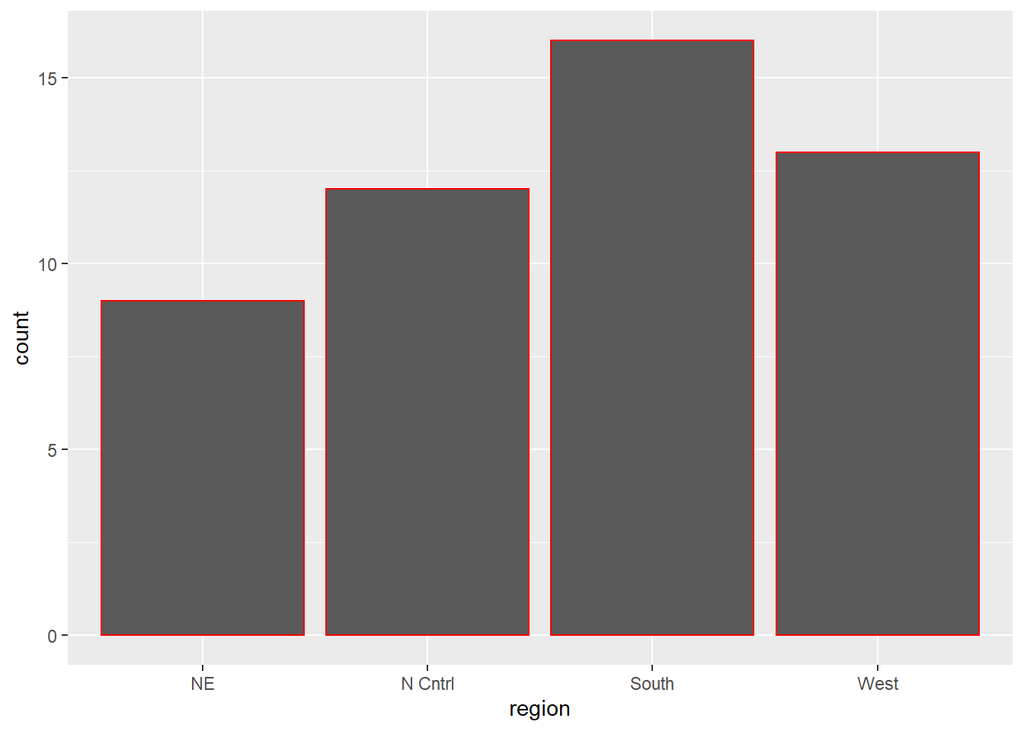

```r
library(ggplot2)
ggp1 <- ggplot(census, aes(x = region)) +
  geom_bar(color  = "red", na.rm = TRUE)

ggp1 + xlim("NE",
            "N Cntrl",
            "South",
            "West")
```

#### Ordena los estados por población, de mayor a menor.

```r
pob_states <- census %>%
  select(state, pop)
arrange(pob_states, desc(pop))
```

```
## # A tibble: 50 x 2
##    state             pop
##    <chr>           <dbl>
##  1 California   23667902
##  2 New York     17558072
##  3 Texas        14229191
##  4 Pennsylvania 11863895
##  5 Illinois     11426518
##  6 Ohio         10797630
##  7 Florida       9746324
##  8 Michigan      9262078
##  9 New Jersey    7364823
## 10 N. Carolina   5881766
## # ... with 40 more rows
```

#### Crea una nueva variable que contenga la tasa de divorcios /matrimonios para cada estado.

```r
divorce_rate <- mutate(census, ratio = divorce/marriage)
# We only select state, pop, marriage, divorce and ratio because of too many columns otherwise
divorce_rate %>%
  select(state,pop,marriage,divorce,ratio)
```

```
## # A tibble: 50 x 5
##    state            pop marriage divorce ratio
##    <chr>          <dbl>    <dbl>   <dbl> <dbl>
##  1 Alabama      3893888    49018   26745 0.546
##  2 Alaska        401851     5361    3517 0.656
##  3 Arizona      2718215    30223   19908 0.659
##  4 Arkansas     2286435    26513   15882 0.599
##  5 California  23667902   210864  133541 0.633
##  6 Colorado     2889964    34917   18571 0.532
##  7 Connecticut  3107576    26048   13488 0.518
##  8 Delaware      594338     4437    2313 0.521
##  9 Florida      9746324   108344   71579 0.661
## 10 Georgia      5463105    70638   34743 0.492
## # ... with 40 more rows
```

#### Si nos preguntamos cuáles son los estados más envejecidos podemos responder de dos maneras. Mirando la edad mediana o mirando en qué estados la franja de mayor edad representa una proporción más alta de la población total. Haz una tabla en la que aparezcan los valores de estos dos criterios, ordenada según la edad mediana decreciente y muestra los 10 primeros estados de esa tabla.

```r
old_table_temp <- census %>%
  select(state, pop, pop65p, medage)

old_table_temp <- mutate(old_table_temp, ratio = pop65p/pop)

old_table <- old_table_temp %>%
  select(state, medage, ratio) %>%
  arrange(desc(medage)) %>%
  head(10)

old_table
```

```
## # A tibble: 10 x 3
##    state         medage ratio
##    <chr>          <dbl> <dbl>
##  1 Florida         34.7 0.173
##  2 New Jersey      32.2 0.117
##  3 Pennsylvania    32.1 0.129
##  4 Connecticut     32   0.117
##  5 New York        31.9 0.123
##  6 Rhode Island    31.8 0.134
##  7 Massachusetts   31.2 0.127
##  8 Missouri        30.9 0.132
##  9 Arkansas        30.6 0.137
## 10 Maine           30.4 0.125
```

#### I Haz un histograma (con 10 intervalos) de los valores de la variable medage (edad mediana) y con la curva de densidad de la variable superpuesta.

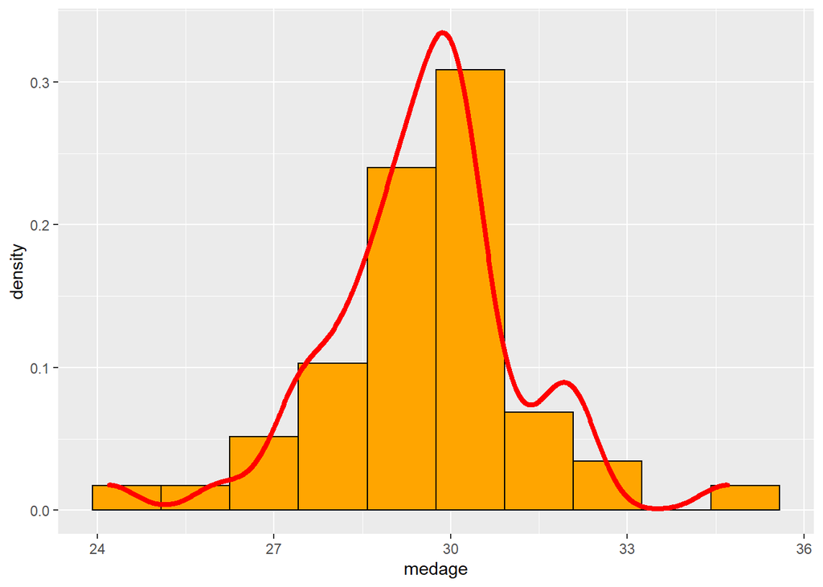

```r
ggplot(census, aes(x = medage)) +
  geom_histogram(aes(y=stat(density)), bins = 10, fill = "orange", color="black") +
  geom_density(color="red", size=1.5)
```

# TAREA 1

#### Carga el conjunto de datos en un data.frame de R llamado chlstrl.

```r
chlstrl <- read_csv("./data/datacholesterol.csv")
```

#### Empezaremos por información básica sobre el conjunto de datos. Cuántas observaciones contiene, cuáles son las variables y de qué tipos

```r
length(chlstrl$chol)
```

```
## [1] 403
```

```r
names(chlstrl)
```

```
## [1] "chol"   "age"    "gender" "height" "weight" "waist"  "hip"
```

```r
str(chlstrl)
```

```
## spec_tbl_df [403 x 7] (S3: spec_tbl_df/tbl_df/tbl/data.frame)
##  $ chol  : num [1:403] 203 165 228 78 249 248 195 227 177 263 ...
##  $ age   : num [1:403] 46 29 58 67 64 34 30 37 45 55 ...
##  $ gender: chr [1:403] "female" "female" "female" "male" ...
##  $ height: num [1:403] 62 64 61 67 68 71 69 59 69 63 ...
##  $ weight: num [1:403] 121 218 256 119 183 190 191 170 166 202 ...
##  $ waist : num [1:403] 29 46 49 33 44 36 46 34 34 45 ...
##  $ hip   : num [1:403] 38 48 57 38 41 42 49 39 40 50 ...
##  - attr(*, "spec")=
##   .. cols(
##   ..   chol = col_double(),
##   ..   age = col_double(),
##   ..   gender = col_character(),
##   ..   height = col_double(),
##   ..   weight = col_double(),
##   ..   waist = col_double(),
##   ..   hip = col_double()
##   .. )
##  - attr(*, "problems")=<externalptr>
```

#### Asegúrate de comprobar si hay datos ausentes y localízalos en la tabla

```r
which(is.na(chlstrl))
```

```
##  [1]   28 1273 1296 1405 1441 1527 1774 2352 2409 2755 2812
```

#### El análisis exploratorio (numérico y gráfico) debe cubrir todos los tipos de variable de la tabla

##### Para las variables cuantitativas (continuas o discretas):

##### - Resumen numérico básico.

##### - Gráficas (las adecuadas, a ser posible más de un tipo de gráfico).

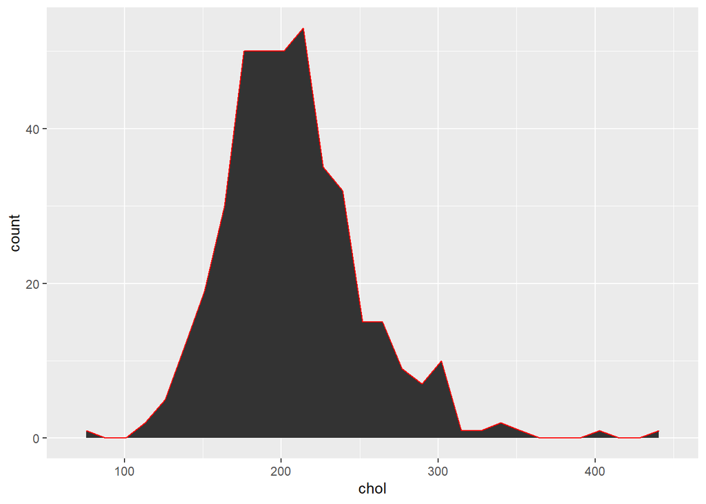

```r
cholesterol <- summarise(chlstrl,
                         count = n(),
                         avgCholesterol = mean(chol, na.rm = TRUE),
                         sdaCholesterol = sd(chol, na.rm = TRUE),
                         medianaCholesterol = median(chol, na.rm = TRUE),
                         Q3rd = quantile(chol, .75, na.rm = TRUE)
                         )


ggplot(chlstrl, aes(x = chol)) +
  geom_area(stat = 'bin', color  = "red", na.rm = TRUE)
```

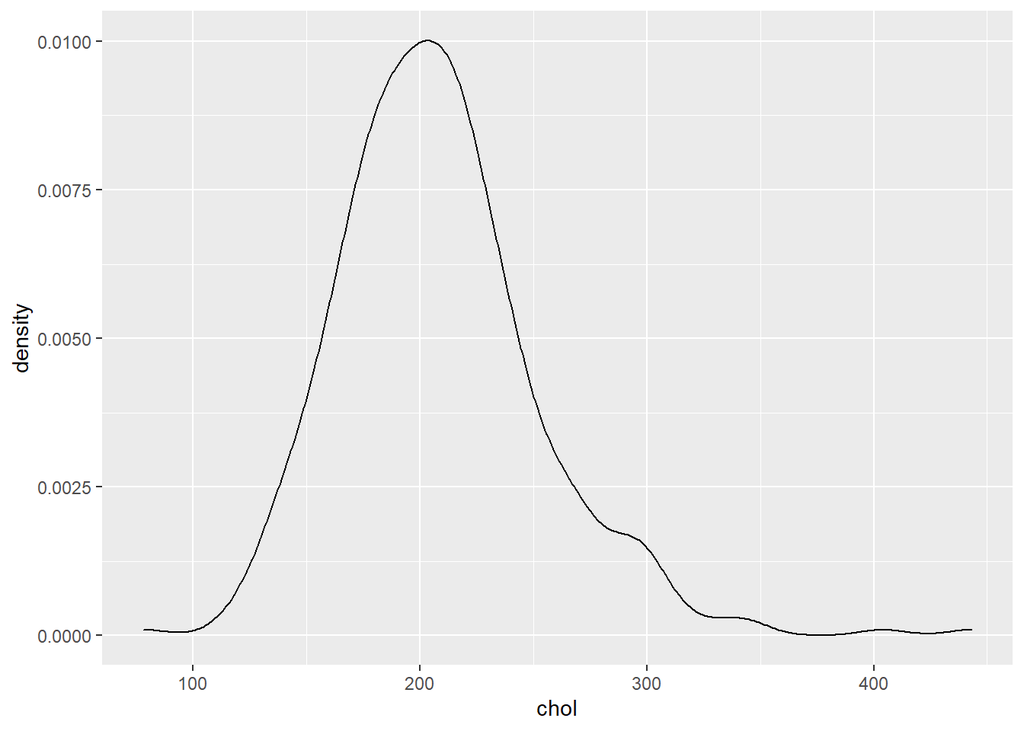

```r
ggplot(chlstrl, aes(x = chol)) +
  geom_density(color  = "black", na.rm = TRUE)
```

##### Variables categóricas (factores):

##### - Tablas de frecuencia (absolutas y relativas).

##### - Gráficas (diagrama de barras).

```r
prop.table(table(chlstrl$gender))
```

```
##
##    female      male
## 0.5806452 0.4193548
```

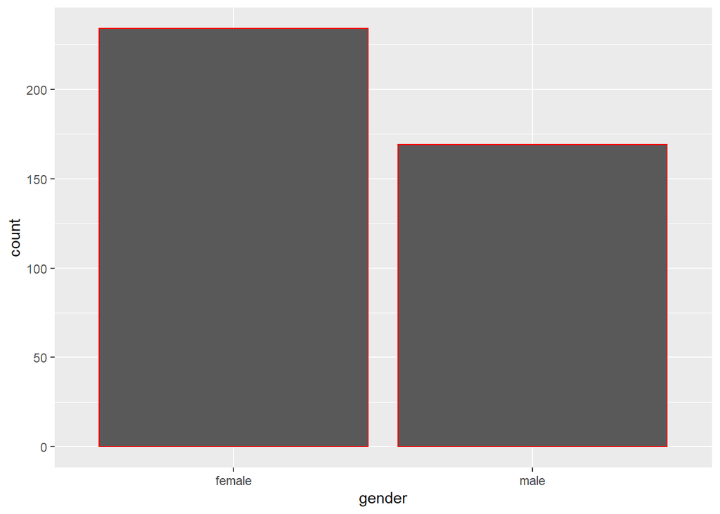

```r
ggplot(chlstrl, aes(x = gender)) +
  geom_bar(color  = "red", na.rm = TRUE)
```

#### Los valores de height y weight están en pulgadas (inches) y libras (pounds) respectivamente. Una libra son ≈ 0.454kg y una pulgada son ≈ 0.0254m. Usa dplyr para convertir esas columnas a metros y kilogramos respectivamente. Las nuevas columnas deben llamarse igual que las originales

#### Ahora usa esos valores de height y weight para añadir una nueva columna llamada BMI, definida mediante

#### Crea una nueva columna llamada ageGroup dividiendo la edad en los siguientes tres niveles:

```r
# Estos pasos se hicieron simultáneamente

chlstrl_BMI <- chlstrl %>%
  mutate(height = height*0.0254,
         weight = weight*0.454,
         BMI = weight/(height^2),
         ageGroup = case_when(age <= 40 ~ '10-40',
                             age > 40 & age <= 70 ~ '40-70',
                             age > 70 & age <= 100 ~ '70-100'
                             )
         )
chlstrl_BMI
```

```
## # A tibble: 403 x 9
##     chol   age gender height weight waist   hip   BMI ageGroup
##    <dbl> <dbl> <chr>   <dbl>  <dbl> <dbl> <dbl> <dbl> <chr>
##  1   203    46 female   1.57   54.9    29    38  22.2 40-70
##  2   165    29 female   1.63   99.0    46    48  37.5 10-40
##  3   228    58 female   1.55  116.     49    57  48.4 40-70
##  4    78    67 male     1.70   54.0    33    38  18.7 40-70
##  5   249    64 male     1.73   83.1    44    41  27.8 40-70
##  6   248    34 male     1.80   86.3    36    42  26.5 10-40
##  7   195    30 male     1.75   86.7    46    49  28.2 10-40
##  8   227    37 male     1.50   77.2    34    39  34.4 10-40
##  9   177    45 male     1.75   75.4    34    40  24.5 40-70
## 10   263    55 female   1.60   91.7    45    50  35.8 40-70
## # ... with 393 more rows
```

#### Usando dplyr calcula cuántas observaciones hay en cada nivel de ageGroup (indicación: usa group_by). Ahora, usando aquellas observaciones que corresponden a mujeres, ¿cuál es la media del nivel de colesterol y de BMI en cada uno de esos grupos de edad

```r
chlstrl_BMI %>%
  group_by(ageGroup) %>%
  summarise(n())
```

```
## # A tibble: 3 x 2
##   ageGroup `n()`
##   <chr>    <int>
## 1 10-40      160
## 2 40-70      207
## 3 70-100      36
```

```r
chlstrl_BMI %>%
  filter(gender == 'female') %>%
  group_by(ageGroup) %>%
  summarise(avgCholesterol = mean(chol, na.rm = TRUE),
            avgBMI = mean(BMI, na.rm = TRUE))
```

```
## # A tibble: 3 x 3
##   ageGroup avgCholesterol avgBMI
##   <chr>             <dbl>  <dbl>
## 1 10-40              189.   30.5
## 2 40-70              221.   30.3
## 3 70-100             230.   29.4
```

```r
chlstrl_BMI
```

```
## # A tibble: 403 x 9
##     chol   age gender height weight waist   hip   BMI ageGroup
##    <dbl> <dbl> <chr>   <dbl>  <dbl> <dbl> <dbl> <dbl> <chr>
##  1   203    46 female   1.57   54.9    29    38  22.2 40-70
##  2   165    29 female   1.63   99.0    46    48  37.5 10-40
##  3   228    58 female   1.55  116.     49    57  48.4 40-70
##  4    78    67 male     1.70   54.0    33    38  18.7 40-70
##  5   249    64 male     1.73   83.1    44    41  27.8 40-70
##  6   248    34 male     1.80   86.3    36    42  26.5 10-40
##  7   195    30 male     1.75   86.7    46    49  28.2 10-40
##  8   227    37 male     1.50   77.2    34    39  34.4 10-40
##  9   177    45 male     1.75   75.4    34    40  24.5 40-70
## 10   263    55 female   1.60   91.7    45    50  35.8 40-70
## # ... with 393 more rows
```

#### Crea una función de R llamada cambiosSigno que dado un vector x de números enteros no nulos, como -> -12, -19, 9, -13, -14, -17, 8, -19, -14 calcule cuántos cambios de signo ha habido. Es decir, cuántas veces el signo de un elemento es distinto del signo del elemento previo. Por ejemplo, en el vector anterior hay 4 cambios de signo (en las posiciones 3, 4, 7 y 8)

```r
X <- sample(-100:100, 20)
X_prueba <- c(-12, -19, 9, -13, -14, -17, 8, -19, -14)
X
```

```
##  [1]  88   8  66  70  17 -20   6  56 -79  74  15 -95  25 -12  29  22  -9  23 -98
## [20] -74
```

```r
cambioSigno = function(x){
  count = sum(diff(sign(x)) != 0)
}

y = cambioSigno(X)
y
```

```
## [1] 11
```

```r
cambioSignoPos = function(x){
  positions = diff(sign(x)) != 0
  which_positions = which(positions == TRUE)
  which_positions = which_positions + 1
}

z = cambioSignoPos(X)
z
```

```
##  [1]  6  7  9 10 12 13 14 15 17 18 19
```

#### Haz el ejercicio 6 de la Sección 3.6.1 de R4DS.

```r
mpg
```

```
## # A tibble: 234 x 11
##    manufacturer model      displ  year   cyl trans drv     cty   hwy fl    class
##    <chr>        <chr>      <dbl> <int> <int> <chr> <chr> <int> <int> <chr> <chr>
##  1 audi         a4           1.8  1999     4 auto~ f        18    29 p     comp~
##  2 audi         a4           1.8  1999     4 manu~ f        21    29 p     comp~
##  3 audi         a4           2    2008     4 manu~ f        20    31 p     comp~
##  4 audi         a4           2    2008     4 auto~ f        21    30 p     comp~
##  5 audi         a4           2.8  1999     6 auto~ f        16    26 p     comp~
##  6 audi         a4           2.8  1999     6 manu~ f        18    26 p     comp~
##  7 audi         a4           3.1  2008     6 auto~ f        18    27 p     comp~
##  8 audi         a4 quattro   1.8  1999     4 manu~ 4        18    26 p     comp~
##  9 audi         a4 quattro   1.8  1999     4 auto~ 4        16    25 p     comp~
## 10 audi         a4 quattro   2    2008     4 manu~ 4        20    28 p     comp~
## # ... with 224 more rows
```

```r
library(grid)
library(gridExtra)
```

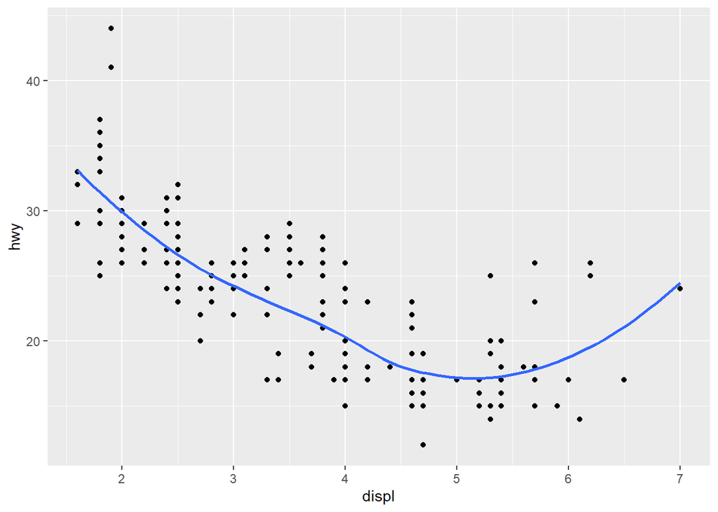

```r
plot1 <- ggplot(mpg, aes(x = displ, y = hwy)) +
  geom_point() +
  geom_smooth(se = FALSE)

plot1
```

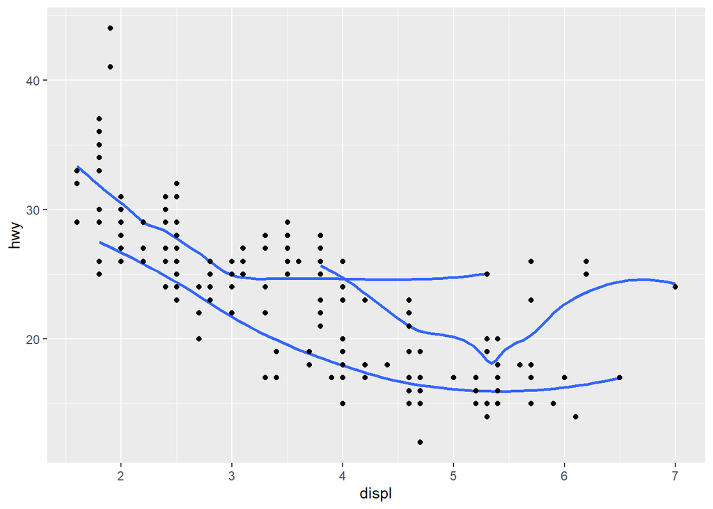

```r
plot2 <- ggplot(mpg, aes(x = displ, y = hwy)) +
  geom_smooth(mapping = aes(group = drv), se = FALSE) +
  geom_point()

plot2
```

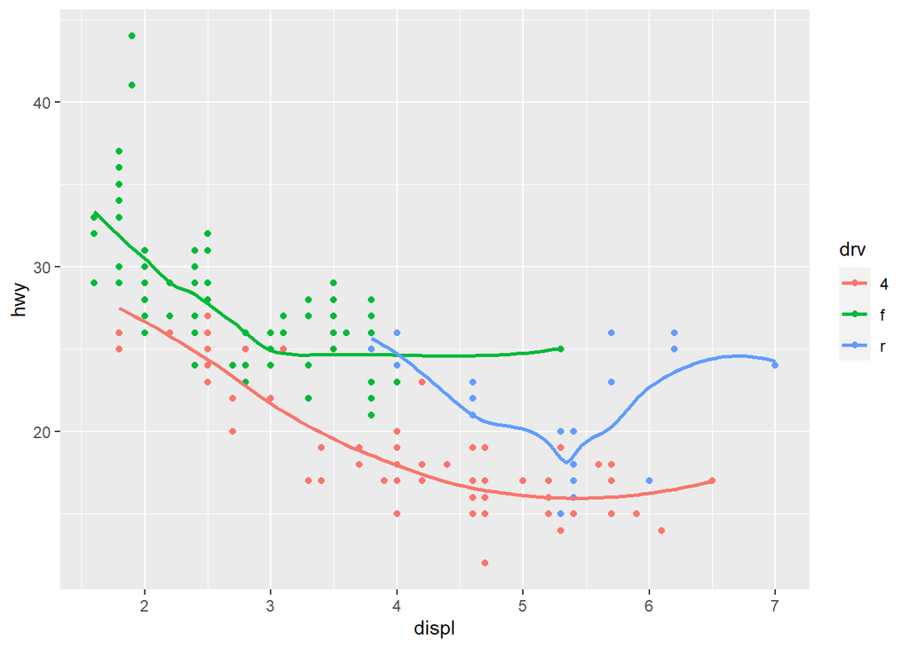

```r
plot3 <- ggplot(mpg, aes(x = displ, y = hwy, colour = drv)) +
  geom_point() +
  geom_smooth(se = FALSE)

plot3
```

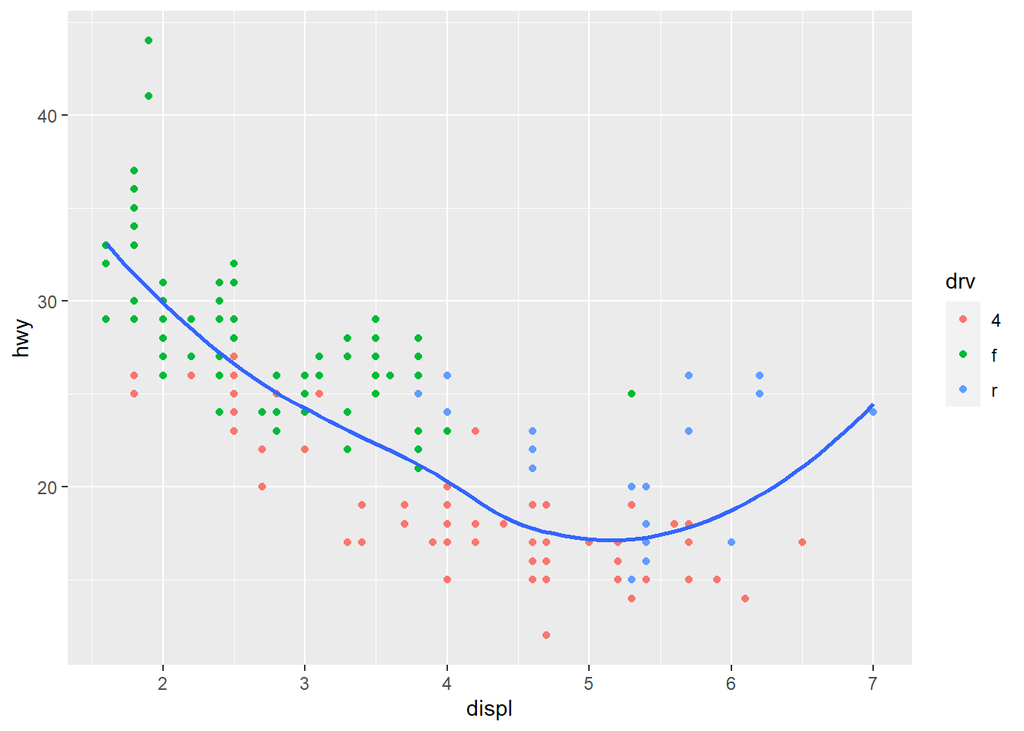

```r
plot4 <-ggplot(mpg, aes(x = displ, y = hwy)) +
  geom_point(aes(colour = drv)) +
  geom_smooth(se = FALSE)

plot4
```

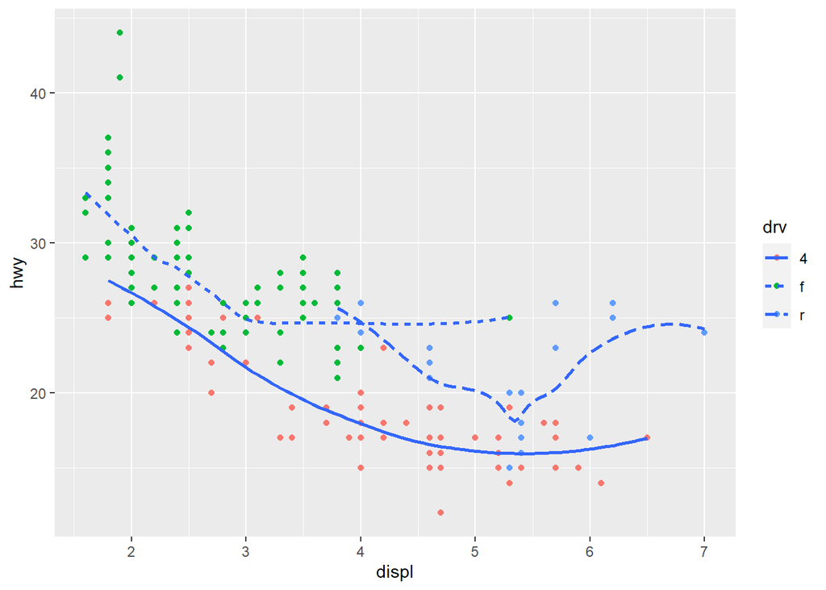

```r
plot5 <- ggplot(mpg, aes(x = displ, y = hwy)) +
  geom_point(aes(colour = drv)) +
  geom_smooth(aes(linetype = drv), se = FALSE)

plot5
```

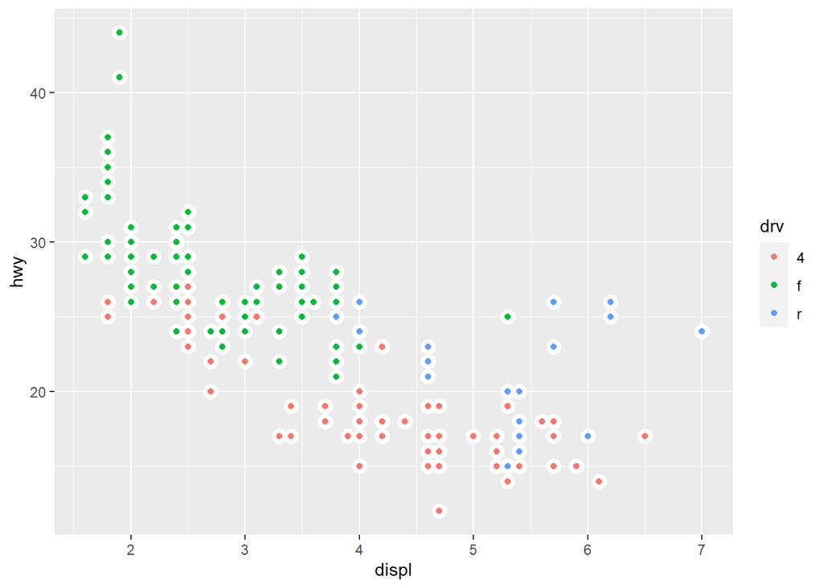

```r
plot6 <-ggplot(mpg, aes(x = displ, y = hwy)) +
  geom_point(size = 4, color = "white") +
  geom_point(aes(colour = drv))

plot6
```

#### Haz el ejercicio 1 de la Sección 5.2.4 de R4DS.

##### 1. Had an arrival delay of two or more hours

```r
library(nycflights13)
filter(flights, arr_delay >= 120)
```

```
## # A tibble: 10,200 x 19
##     year month   day dep_time sched_dep_time dep_delay arr_time sched_arr_time
##    <int> <int> <int>    <int>          <int>     <dbl>    <int>          <int>
##  1  2013     1     1      811            630       101     1047            830
##  2  2013     1     1      848           1835       853     1001           1950
##  3  2013     1     1      957            733       144     1056            853
##  4  2013     1     1     1114            900       134     1447           1222
##  5  2013     1     1     1505           1310       115     1638           1431
##  6  2013     1     1     1525           1340       105     1831           1626
##  7  2013     1     1     1549           1445        64     1912           1656
##  8  2013     1     1     1558           1359       119     1718           1515
##  9  2013     1     1     1732           1630        62     2028           1825
## 10  2013     1     1     1803           1620       103     2008           1750
## # ... with 10,190 more rows, and 11 more variables: arr_delay <dbl>,
## #   carrier <chr>, flight <int>, tailnum <chr>, origin <chr>, dest <chr>,
## #   air_time <dbl>, distance <dbl>, hour <dbl>, minute <dbl>, time_hour <dttm>
```

##### 2. Flew to Houston (IAH or HOU)

```r
filter(flights, dest == "IAH" | dest == "HOU")
```

```
## # A tibble: 9,313 x 19
##     year month   day dep_time sched_dep_time dep_delay arr_time sched_arr_time
##    <int> <int> <int>    <int>          <int>     <dbl>    <int>          <int>
##  1  2013     1     1      517            515         2      830            819
##  2  2013     1     1      533            529         4      850            830
##  3  2013     1     1      623            627        -4      933            932
##  4  2013     1     1      728            732        -4     1041           1038
##  5  2013     1     1      739            739         0     1104           1038
##  6  2013     1     1      908            908         0     1228           1219
##  7  2013     1     1     1028           1026         2     1350           1339
##  8  2013     1     1     1044           1045        -1     1352           1351
##  9  2013     1     1     1114            900       134     1447           1222
## 10  2013     1     1     1205           1200         5     1503           1505
## # ... with 9,303 more rows, and 11 more variables: arr_delay <dbl>,
## #   carrier <chr>, flight <int>, tailnum <chr>, origin <chr>, dest <chr>,
## #   air_time <dbl>, distance <dbl>, hour <dbl>, minute <dbl>, time_hour <dttm>
```

##### 3. Were operated by United, American, or Delta

```r
airlines
```

```
## # A tibble: 16 x 2
##    carrier name
##    <chr>   <chr>
##  1 9E      Endeavor Air Inc.
##  2 AA      American Airlines Inc.
##  3 AS      Alaska Airlines Inc.
##  4 B6      JetBlue Airways
##  5 DL      Delta Air Lines Inc.
##  6 EV      ExpressJet Airlines Inc.
##  7 F9      Frontier Airlines Inc.
##  8 FL      AirTran Airways Corporation
##  9 HA      Hawaiian Airlines Inc.
## 10 MQ      Envoy Air
## 11 OO      SkyWest Airlines Inc.
## 12 UA      United Air Lines Inc.
## 13 US      US Airways Inc.
## 14 VX      Virgin America
## 15 WN      Southwest Airlines Co.
## 16 YV      Mesa Airlines Inc.
```

```r
filter(flights, carrier %in% c("AA", "DL", "UA"))
```

```
## # A tibble: 139,504 x 19
##     year month   day dep_time sched_dep_time dep_delay arr_time sched_arr_time
##    <int> <int> <int>    <int>          <int>     <dbl>    <int>          <int>
##  1  2013     1     1      517            515         2      830            819
##  2  2013     1     1      533            529         4      850            830
##  3  2013     1     1      542            540         2      923            850
##  4  2013     1     1      554            600        -6      812            837
##  5  2013     1     1      554            558        -4      740            728
##  6  2013     1     1      558            600        -2      753            745
##  7  2013     1     1      558            600        -2      924            917
##  8  2013     1     1      558            600        -2      923            937
##  9  2013     1     1      559            600        -1      941            910
## 10  2013     1     1      559            600        -1      854            902
## # ... with 139,494 more rows, and 11 more variables: arr_delay <dbl>,
## #   carrier <chr>, flight <int>, tailnum <chr>, origin <chr>, dest <chr>,
## #   air_time <dbl>, distance <dbl>, hour <dbl>, minute <dbl>, time_hour <dttm>
```

##### 4. Departed in summer (July, August, and September)

```r
filter(flights, month >= 7, month <= 9)
```

```
## # A tibble: 86,326 x 19
##     year month   day dep_time sched_dep_time dep_delay arr_time sched_arr_time
##    <int> <int> <int>    <int>          <int>     <dbl>    <int>          <int>
##  1  2013     7     1        1           2029       212      236           2359
##  2  2013     7     1        2           2359         3      344            344
##  3  2013     7     1       29           2245       104      151              1
##  4  2013     7     1       43           2130       193      322             14
##  5  2013     7     1       44           2150       174      300            100
##  6  2013     7     1       46           2051       235      304           2358
##  7  2013     7     1       48           2001       287      308           2305
##  8  2013     7     1       58           2155       183      335             43
##  9  2013     7     1      100           2146       194      327             30
## 10  2013     7     1      100           2245       135      337            135
## # ... with 86,316 more rows, and 11 more variables: arr_delay <dbl>,
## #   carrier <chr>, flight <int>, tailnum <chr>, origin <chr>, dest <chr>,
## #   air_time <dbl>, distance <dbl>, hour <dbl>, minute <dbl>, time_hour <dttm>
```

##### 5. Arrived more than two hours late, but didn’t leave late

```r
filter(flights, arr_delay > 120, dep_delay <= 0)
```

```
## # A tibble: 29 x 19
##     year month   day dep_time sched_dep_time dep_delay arr_time sched_arr_time
##    <int> <int> <int>    <int>          <int>     <dbl>    <int>          <int>
##  1  2013     1    27     1419           1420        -1     1754           1550
##  2  2013    10     7     1350           1350         0     1736           1526
##  3  2013    10     7     1357           1359        -2     1858           1654
##  4  2013    10    16      657            700        -3     1258           1056
##  5  2013    11     1      658            700        -2     1329           1015
##  6  2013     3    18     1844           1847        -3       39           2219
##  7  2013     4    17     1635           1640        -5     2049           1845
##  8  2013     4    18      558            600        -2     1149            850
##  9  2013     4    18      655            700        -5     1213            950
## 10  2013     5    22     1827           1830        -3     2217           2010
## # ... with 19 more rows, and 11 more variables: arr_delay <dbl>, carrier <chr>,
## #   flight <int>, tailnum <chr>, origin <chr>, dest <chr>, air_time <dbl>,
## #   distance <dbl>, hour <dbl>, minute <dbl>, time_hour <dttm>
```

##### 6. Were delayed by at least an hour, but made up over 30 minutes in flight

```r
filter(flights, dep_delay >= 60, dep_delay - arr_delay > 30)
```

```
## # A tibble: 1,844 x 19
##     year month   day dep_time sched_dep_time dep_delay arr_time sched_arr_time
##    <int> <int> <int>    <int>          <int>     <dbl>    <int>          <int>
##  1  2013     1     1     2205           1720       285       46           2040
##  2  2013     1     1     2326           2130       116      131             18
##  3  2013     1     3     1503           1221       162     1803           1555
##  4  2013     1     3     1839           1700        99     2056           1950
##  5  2013     1     3     1850           1745        65     2148           2120
##  6  2013     1     3     1941           1759       102     2246           2139
##  7  2013     1     3     1950           1845        65     2228           2227
##  8  2013     1     3     2015           1915        60     2135           2111
##  9  2013     1     3     2257           2000       177       45           2224
## 10  2013     1     4     1917           1700       137     2135           1950
## # ... with 1,834 more rows, and 11 more variables: arr_delay <dbl>,
## #   carrier <chr>, flight <int>, tailnum <chr>, origin <chr>, dest <chr>,
## #   air_time <dbl>, distance <dbl>, hour <dbl>, minute <dbl>, time_hour <dttm>
```

##### 7. Departed between midnight and 6am (inclusive)

```r
summary(flights$dep_time)
```

```
##    Min. 1st Qu.  Median    Mean 3rd Qu.    Max.    NA's
##       1     907    1401    1349    1744    2400    8255
```

```r
# In dep_time, midnight is represented by 2400, not 0
```

```r
filter(flights, dep_time <= 600 | dep_time == 2400)
```

```
## # A tibble: 9,373 x 19
##     year month   day dep_time sched_dep_time dep_delay arr_time sched_arr_time
##    <int> <int> <int>    <int>          <int>     <dbl>    <int>          <int>
##  1  2013     1     1      517            515         2      830            819
##  2  2013     1     1      533            529         4      850            830
##  3  2013     1     1      542            540         2      923            850
##  4  2013     1     1      544            545        -1     1004           1022
##  5  2013     1     1      554            600        -6      812            837
##  6  2013     1     1      554            558        -4      740            728
##  7  2013     1     1      555            600        -5      913            854
##  8  2013     1     1      557            600        -3      709            723
##  9  2013     1     1      557            600        -3      838            846
## 10  2013     1     1      558            600        -2      753            745
## # ... with 9,363 more rows, and 11 more variables: arr_delay <dbl>,
## #   carrier <chr>, flight <int>, tailnum <chr>, origin <chr>, dest <chr>,
## #   air_time <dbl>, distance <dbl>, hour <dbl>, minute <dbl>, time_hour <dttm>
```